# Reshaping and Joining Data in R with dplyr

Lubov McKone

Johns Hopkins Libraries Data Services

2026-09-26

## Welcome!

Please feel free to ask questions verbally or in the chat, and I will do my best to answer them as we move through the training today.

We will take a break halfway through the training.

## Recording logistics

Your continued participation indicates your consent to be recorded. This recording may be shared with the JHU community.

Any questions you ask verbally or in chat will be edited to protect your identity.

## Troubleshooting and assistance

If you have questions throughout the webinar, include the error message you receive and the line of code that caused it.

Screenshots can also be helpful

## JHU Data Services

### We help faculty, researchers, and students find, use, manage, visualize, and share data.

- Find out more at dataservices.library.jhu.edu
- Email us for a consultation at dataservices@jhu.edu
- Share your research data at archive.data.jhu.edu

## What you will learn today

- How to reshape data using the powerful `dplyr` package
  - Calculate new variables to analyze
  - Summarize data differently to suit your unit of analysis
  - Sort data to make it easier to visualize
- How to use the pipe `|>` to simplify code
- How to join two datasets together using different approaches and conditions
- Additional resources for manipulating and joining data using `dplyr`

## You should have:

- A template R script that we will fill out today called `class_script_blank.R`
- dplyr cheatsheet
- Basic knowledge of R
  - Installing and loading packages
  - Basic terminology of R or programming in general

## Libraries

Today we’ll be using the tidyverse library, which includes dplyr.

```r
library(tidyverse)
```

## Review: reading and viewing data

```r
# we'll be looking at data on Groundhog predictions
groundhogs <- readr::read_csv('https://raw.githubusercontent.com/rfordatascience/tidytuesday/master/data/2024/2024-01-30/groundhogs.csv')
predictions <- readr::read_csv('https://raw.githubusercontent.com/rfordatascience/tidytuesday/master/data/2024/2024-01-30/predictions.csv')
```

You can view a dataframe in R using `View()` or by clicking the object in the environment pane.

Let’s take a look at our groundhog predictions dataset:

```r
head(predictions)
```

| id | year | shadow | details |
| --- | --- | --- | --- |
| 1 | 1886 | NA | Groundhog Day first recognized in Punxsutawney by Weathers Wags. |
| 1 | 1887 | TRUE | First Official trek to Gobbler’s Knob. Saw Shadow. |
| 1 | 1888 | TRUE | Saw Shadow. |
| 1 | 1889 | NA | No Record. |
| 1 | 1890 | FALSE | No Shadow. |
| 1 | 1891 | NA | No Record. |

## Groundhog Day 🕳️

According to Pennsylvania Dutch superstition, if a groundhog emerges from its burrow on February 2 and sees its shadow, winter will continue for 6 more weeks. No shadow means an early spring! The first and most famous prophesying groundhog is Punxsutawney Phil, but [87 other groundhogs have followed in his footsteps](https://groundhog-day.com/groundhogs), making their own predictions each year.

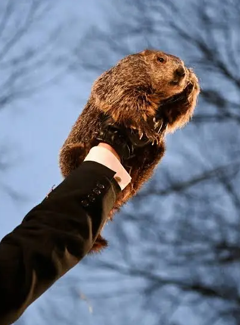

## Our task today

- We are researchers studying whether groundhogs can really predict an early spring.
- To start our research, we’ll need to conduct some exploratory analyses about patterns in groundhog predictions so we can compare them to weather trends.
- Over the course of this workshop, we’ll be creating summary tables that will set us up for further visualization and analysis.

## The dplyr package

- dplyr is a “grammar” of data manipulation
- dplyr is a set of R functions that work together to help you solve the most common data manipulation challenges, like:
  - Filtering out certain rows and sorting your data
  - Calculating a new column based on existing columns
  - Grouping and summarizing data
  - Joining data from different sources

[figure not shown]

## dplyr grammar

- dplyr’s core is a set functions that can be divided into 4 groups based on what they operate across:
  - rows
  - columns
  - groups
  - tables
- We’ll call these the dplyr *verbs*
- dplyr also contains a number of useful *helper functions* that operate on single values or arrays. We’ll introduce those along the way.

## anatomy of a dplyr verb

In every dplyr verb:

- the first argument is always dataframe
- The subsequent arguments describe what to do with the dataframe, using the variable names (without quotes)
- the output is always a new dataframe
- arguments with a . in front of them are settings for the function, not variable names

## row verbs

- `filter()` : keep rows based on the value of one or more columns
- `arrange()`: changes the row order based on one or more columns
- `distinct()`: finds all the unique rows based on the values of one or more columns

## row verbs: `filter()`

- `filter()` : keep rows based on the value of one or more columns
- You can compose conditions using `==`, `>`, `<`, `>=`, `<=`, `!=`, and include multiple conditions using `&` or `|`
- The `%in%` operator can serve as a combination of `|` and `==`

## row verbs: `filter()`

```r
# find groundhog predictions from 2020
filter(predictions, year == 2020)
```

| id | year | shadow | details |
| --- | --- | --- | --- |
| 1 | 2020 | FALSE | NO Shadow at 7:26 AM; 30º with light snow falling. |
| 2 | 2020 | FALSE | NA |
| 3 | 2020 | TRUE | Shadow, Six More Weeks of Winter! |
| 4 | 2020 | TRUE | NA |
| 5 | 2020 | TRUE | NA |
| 6 | 2020 | FALSE | NA |
| 7 | 2020 | TRUE | NA |
| 8 | 2020 | FALSE | NA |
| 9 | 2020 | TRUE | NA |
| 10 | 2020 | FALSE | NA |

[output cut: 57 more lines]

```r
# find groundhog predictions from 2020 and 2021
filter(predictions, year == 2020 | year == 2021)
```

| id | year | shadow | details |
| --- | --- | --- | --- |
| 1 | 2020 | FALSE | NO Shadow at 7:26 AM; 30º with light snow falling. |
| 1 | 2021 | TRUE | Shadow at 7:25 AM; 19º with light snow. Coronavirus fear prohibits crowds on Gobbler’s Knob. |
| 2 | 2020 | FALSE | NA |
| 2 | 2021 | NA | NA |
| 3 | 2020 | TRUE | Shadow, Six More Weeks of Winter! |
| 3 | 2021 | FALSE | No Shadow, Early Spring! |
| 4 | 2020 | TRUE | NA |
| 4 | 2021 | FALSE | NA |
| 5 | 2020 | TRUE | NA |
| 5 | 2021 | FALSE | NA |

[output cut: 126 more lines]

```r
filter(predictions, year %in% c(2020, 2021))
```

| id | year | shadow | details |
| --- | --- | --- | --- |
| 1 | 2020 | FALSE | NO Shadow at 7:26 AM; 30º with light snow falling. |
| 1 | 2021 | TRUE | Shadow at 7:25 AM; 19º with light snow. Coronavirus fear prohibits crowds on Gobbler’s Knob. |
| 2 | 2020 | FALSE | NA |
| 2 | 2021 | NA | NA |
| 3 | 2020 | TRUE | Shadow, Six More Weeks of Winter! |
| 3 | 2021 | FALSE | No Shadow, Early Spring! |
| 4 | 2020 | TRUE | NA |
| 4 | 2021 | FALSE | NA |
| 5 | 2020 | TRUE | NA |
| 5 | 2021 | FALSE | NA |

[output cut: 126 more lines]

## `filter()`: your turn!

Find groundhog predictions between 1900 and 2000. Bonus: Use the pipe in your answer!

## `filter()`: your turn!

```r
# find predictions between 1900 and 2000
predictions |>
  filter(year >= 1900 & year <= 2000)
```

| id | year | shadow | details |
| --- | --- | --- | --- |
| 1 | 1900 | TRUE | Saw Shadow. |
| 1 | 1901 | TRUE | Saw Shadow. |
| 1 | 1902 | FALSE | Probably No Shadow. |
| 1 | 1903 | TRUE | Saw Shadow. |
| 1 | 1904 | TRUE | Saw Shadow. |
| 1 | 1905 | TRUE | Saw Shadow. |
| 1 | 1906 | TRUE | Saw Shadow. |
| 1 | 1907 | TRUE | Saw Shadow. |
| 1 | 1908 | TRUE | Saw Shadow; First front page coverage |
| 1 | 1909 | TRUE | Saw Shadow. |

[output cut: 411 more lines]

## `filter()`: useful helper functions

- `between()` tests if a variable falls between two values (inclusive)
- `near()` tests if a variable is within a certain range of a given number (you can set the tolerance)
- `is.na()` tests whether the variable is NA. Use is conjunction with `!` to filter for non-NA values.

## row verbs: `arrange()`

`arrange()`: changes the row order based on one or more columns

You can wrap the columns with `desc()` to sort in descending order

```r
# sort our predictions by year
arrange(predictions, year)
```

| id | year | shadow | details |
| --- | --- | --- | --- |
| 1 | 1886 | NA | Groundhog Day first recognized in Punxsutawney by Weathers Wags. |
| 1 | 1887 | TRUE | First Official trek to Gobbler’s Knob. Saw Shadow. |
| 1 | 1888 | TRUE | Saw Shadow. |
| 1 | 1889 | NA | No Record. |
| 1 | 1890 | FALSE | No Shadow. |
| 1 | 1891 | NA | No Record. |
| 1 | 1892 | NA | No Record. |
| 1 | 1893 | NA | No Record. |
| 1 | 1894 | NA | No Record. |
| 1 | 1895 | NA | No Record. |

[output cut: 1452 more lines]

```r
# sort our predictions by year, descending
arrange(predictions, desc(year))
```

| id | year | shadow | details |
| --- | --- | --- | --- |
| 1 | 2023 | TRUE | Shadow at 7:24 AM; 13º with clear skies. PA Governor Josh Shapiro attends. Thousands of Eagles Super Bowl LVII fans help celebrate Phil’s big day at the Knob. |
| 2 | 2023 | FALSE | NA |
| 3 | 2023 | FALSE | No Shadow, Early Spring! |
| 4 | 2023 | TRUE | NA |
| 5 | 2023 | FALSE | NA |
| 6 | 2023 | TRUE | NA |
| 7 | 2023 | FALSE | NA |
| 8 | 2023 | FALSE | NA |
| 9 | 2023 | TRUE | NA |
| 10 | 2023 | FALSE | NA |

[output cut: 1452 more lines]